# Praca domowa 4

Aleksandra Dąbrowska

22 March 2017

# Zadanie

Znajdź przykładowe dane na których można wykonać analizę dwukierunkową crossed i nested (mogą być to różne zbiory danych).

# Dane

Zajmuję się danymi `auta2012` z pakietu `PogromcyDanych`. Do modelowania wybieram tylko część danych, ponieważ działanie na wszytskich poziomach zmiennych może zająć bardzo dużo czasu.

```r
library(dplyr)
library(PogromcyDanych)
library(lattice)
```

```r
auta <- PogromcyDanych::auta2012

auta <- auta[,c(3,4,7,8,10,13,14,15,19)]
auta$Rok.produkcji <- as.factor(auta$Rok.produkcji)

auta2 <-  filter(auta, Marka %in% c("Kia","Volvo","Renault","Lexus"))

auta2 <- auta2[which(auta2$Liczba.drzwi!=""),]
auta2 <- auta2[which(auta2$Rodzaj.paliwa!=""),]
auta2 <- auta2[which(auta2$Skrzynia.biegow!=""),]
auta2 <- auta2[which(auta2$Kolor!=""),]
auta2 <- auta2[which(auta2$Brutto.netto=="brutto"),]



auta2 <- droplevels(auta2)

head(auta2, 5)
```

```
##   Cena.w.PLN Brutto.netto   Marka        Model Liczba.drzwi
## 2      25900       brutto   Volvo          S80          4/5
## 3      39900       brutto Renault       Trafic          4/5
## 4     116800       brutto   Volvo        XC 70          4/5
## 6      27900       brutto Renault       Megane          4/5
## 7      31900       brutto Renault Grand Scenic          4/5
##            Rodzaj.paliwa Rok.produkcji              Kolor Skrzynia.biegow
## 2 olej napedowy (diesel)          2003   srebrny-metallic        manualna
## 3 olej napedowy (diesel)          2006   srebrny-metallic        manualna
## 4                benzyna          2009   srebrny-metallic    automatyczna
## 6 olej napedowy (diesel)          2008   bordowy-metallic        manualna
## 7 olej napedowy (diesel)          2007 grafitowy-metallic        manualna
```

# Analiza

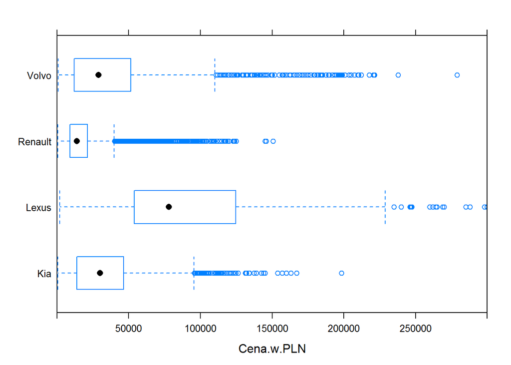

```r
bwplot(Marka~Cena.w.PLN,data=auta2,xlim=c(0:300000))
```

# Crossed

W powyższych danych możemy znaleźć zmienne jakościowe o przecinających się poziomach. Są to między innymi: `Rodzaj.paliwa`, `Skrzynia.biegow`, `Liczba.drzwi`,`Kolor`.

```r
levels(auta2$Rodzaj.paliwa)
```

```
## [1] "benzyna"                "benzyna+LPG"
## [3] "hybryda"                "naped elektryczny"
## [5] "olej napedowy (diesel)"
```

```r
levels(auta2$Liczba.drzwi)
```

```
## [1] "2/3" "4/5"
```

```r
levels(auta2$Skrzynia.biegow)
```

```
## [1] "automatyczna" "manualna"
```

### Model 1

Pierwszy model liniowy opieram o dwie przecinające się zmienne `Rodzaj.paliwa` i `Skrzynia.biegow`.

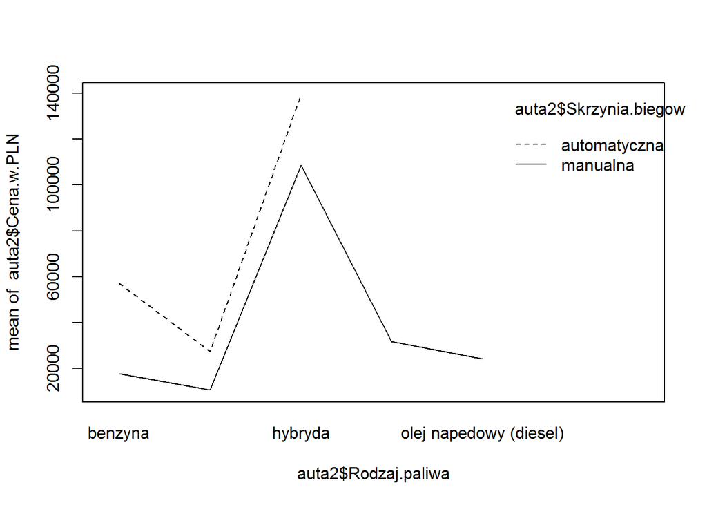

```r
interaction.plot(auta2$Rodzaj.paliwa,auta2$Skrzynia.biegow,auta2$Cena.w.PLN)
```

```r
model_crossed_1 <- aov(Cena.w.PLN~Rodzaj.paliwa*Skrzynia.biegow, data=auta2)

summary(model_crossed_1)
```

```
##                                  Df    Sum Sq   Mean Sq F value Pr(>F)
## Rodzaj.paliwa                     4 8.766e+11 2.192e+11  307.54 <2e-16 ***
## Skrzynia.biegow                   1 2.068e+12 2.068e+12 2902.07 <2e-16 ***
## Rodzaj.paliwa:Skrzynia.biegow     3 6.064e+10 2.021e+10   28.36 <2e-16 ***
## Residuals                     19217 1.369e+13 7.126e+08
## ---
## Signif. codes:  0 '***' 0.001 '**' 0.01 '*' 0.05 '.' 0.1 ' ' 1
```

Jak widać istnieje interakcja między zmiennymi `Skrzynia.biegow` i`Rodzaj.paliwa`.

### Model 2

Następny model opieramo kolejną parę zmiennych przecinających się : `Liczba.drzwi` i `Skrzynia.biegow`.

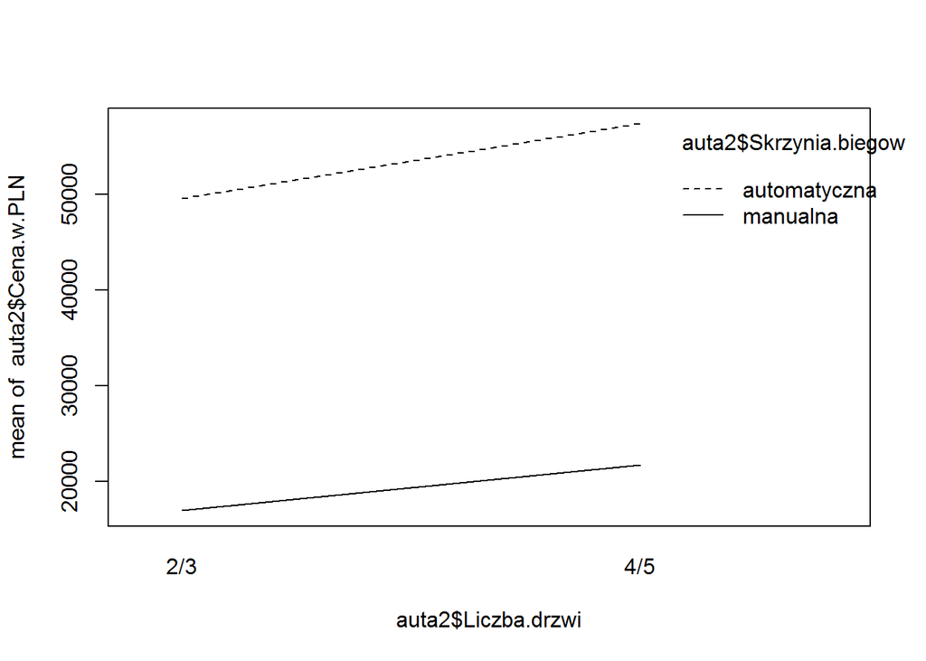

```r
interaction.plot(auta2$Liczba.drzwi,auta2$Skrzynia.biegow,auta2$Cena.w.PLN)
```

```r
model_crossed_2 <- aov(Cena.w.PLN~Skrzynia.biegow*Liczba.drzwi, data=auta2)

summary(model_crossed_2)
```

```
##                                 Df    Sum Sq   Mean Sq  F value   Pr(>F)
## Skrzynia.biegow                  1 2.257e+12 2.257e+12 3012.530  < 2e-16
## Liczba.drzwi                     1 4.263e+10 4.263e+10   56.905 4.78e-14
## Skrzynia.biegow:Liczba.drzwi     1 7.337e+08 7.337e+08    0.979    0.322
## Residuals                    19222 1.440e+13 7.491e+08
##
## Skrzynia.biegow              ***
## Liczba.drzwi                 ***
## Skrzynia.biegow:Liczba.drzwi
## Residuals
## ---
## Signif. codes:  0 '***' 0.001 '**' 0.01 '*' 0.05 '.' 0.1 ' ' 1
```

Jednak w tym przypadku widzimy, zarówno na wykresie `interaction.plot()` jak i używając funkcji `aov()`, że nie ma interakcji między zmiennymi.

# Nested

W zbiorze danych `auta2012` możemy wyróżnić zmienną `Model`, która jest zagnieżdzona w zmiennej `Marka`.

## Model

```r
model_nested <- aov(Cena.w.PLN~Marka/Model, data=auta2)
summary(model_nested)
```

```
##                Df    Sum Sq   Mean Sq F value Pr(>F)
## Marka           3 3.613e+12 1.204e+12  2961.5 <2e-16 ***
## Marka:Model   111 5.315e+12 4.789e+10   117.8 <2e-16 ***
## Residuals   19111 7.772e+12 4.067e+08
## ---
## Signif. codes:  0 '***' 0.001 '**' 0.01 '*' 0.05 '.' 0.1 ' ' 1
```

Zagnieżdzona zmienna `Model` w istotnim stopniu objaśnia zmienną `Cena.w.PLN`.

# Model z wieloma czynnikami

Na koniec, chcę zbudować model oparty na wielu czynnikach ze zbioru `auta2`, tak aby wyróżnić zmienne istotne.

```r
model_pelny <- aov(Cena.w.PLN~Marka/Model+Rodzaj.paliwa+Rok.produkcji+Skrzynia.biegow+Kolor+Liczba.drzwi,data=auta2)
summary(model_pelny)
```

```
##                    Df    Sum Sq   Mean Sq F value   Pr(>F)
## Marka               3 3.613e+12 1.204e+12 6297.31  < 2e-16 ***
## Rodzaj.paliwa       4 4.057e+11 1.014e+11  530.29  < 2e-16 ***
## Rok.produkcji      39 5.952e+12 1.526e+11  798.01  < 2e-16 ***
## Skrzynia.biegow     1 4.590e+11 4.590e+11 2400.30  < 2e-16 ***
## Kolor              35 8.487e+10 2.425e+09   12.68  < 2e-16 ***
## Liczba.drzwi        1 9.346e+09 9.346e+09   48.87 2.83e-12 ***
## Marka:Model       108 2.536e+12 2.348e+10  122.78  < 2e-16 ***
## Residuals       19034 3.640e+12 1.912e+08
## ---
## Signif. codes:  0 '***' 0.001 '**' 0.01 '*' 0.05 '.' 0.1 ' ' 1
```

Dla tego zbioru danych wszystkie zmienne są istotne.